# Phase 2: Deep Learning Demand Forecasting

Rathina Grace Monica

2026-04-29

## 1. Initializing AI Backend

To power our predictive engine, we utilize H2O.ai, an industry-standard platform for distributed machine learning. This allows us to scale our urban transport predictions efficiently.

## 2. Data Preparation & H2O Conversion

Before training, we must convert our standard R dataframe into an H2O Frame. This “hands over” the data to the AI engine for high-speed processing.

```r
# Convert to H2O Frame
h2o_data <- as.h2o(data)
```

[output not shown]

## 3. Training vs. Testing Split

We employ a rigorous 80/20 split. 80% of the data is used to “teach” the AI, while 20% is held back as a “final exam” to test its accuracy on unseen scenarios.

```r
data_split <- h2o.splitFrame(data = h2o_data, ratios = 0.8, seed = 2026)
train_data <- data_split[[1]]
test_data  <- data_split[[2]]

print(paste("Training Records:", nrow(train_data)))
```

```
## [1] "Training Records: 811"
```

```r
print(paste("Testing Records:", nrow(test_data)))
```

```
## [1] "Testing Records: 189"
```

## 4. Training the Deep Learning “Brain”

Our model features a Multi-Layer Perceptron (MLP) architecture with 3 hidden layers of 32 neurons each. We iterate (epochs) 50 times to minimize prediction error.

```r
target     <- "CommuterDemand"
features   <- c("TaxiCount", "Latitude", "Longitude")

urban_model <- h2o.deeplearning(
  x = features,
  y = target,
  training_frame = train_data,
  model_id = "SG_Transport_Model_v1",
  hidden = c(32, 32, 32),
  epochs = 50,
  variable_importances = TRUE
)
```

[output not shown]

## 5. Model Summary

```r
# Now that it's done, let's see how it performed on its own training data.
print("Training Complete! Here is the model summary:")
```

```
## [1] "Training Complete! Here is the model summary:"
```

```r
summary(urban_model)
```

```
## Model Details:
## ==============
##
## H2ORegressionModel: deeplearning
## Model Key:  SG_Transport_Model_v1
## Status of Neuron Layers: predicting CommuterDemand, regression, gaussian distribution, Quadratic loss, 2,273 weights/biases, 31.9 KB, 40,550 training samples, mini-batch size 1
##   layer units      type dropout       l1       l2 mean_rate rate_rms momentum
## 1     1     3     Input  0.00 %       NA       NA        NA       NA       NA
## 2     2    32 Rectifier  0.00 % 0.000000 0.000000  0.003655 0.001869 0.000000
## 3     3    32 Rectifier  0.00 % 0.000000 0.000000  0.010453 0.007105 0.000000
## 4     4    32 Rectifier  0.00 % 0.000000 0.000000  0.032603 0.093163 0.000000
## 5     5     1    Linear      NA 0.000000 0.000000  0.002803 0.007776 0.000000
##   mean_weight weight_rms mean_bias bias_rms
## 1          NA         NA        NA       NA
## 2    0.006056   0.224937  0.461835 0.092545
## 3   -0.039981   0.185315  0.923171 0.056316
## 4   -0.030957   0.185465  0.960854 0.040743
## 5   -0.033604   0.203091  0.013874 0.000000
##
## H2ORegressionMetrics: deeplearning
## ** Reported on training data. **
## ** Metrics reported on full training frame **
##
## MSE:  24.82091
## RMSE:  4.982059
## MAE:  3.956452
## RMSLE:  0.03564639
## Mean Residual Deviance :  24.82091
##
##
##
##
##
## Scoring History:
##             timestamp   duration training_speed   epochs iterations
## 1 2026-05-02 18:44:24  0.000 sec             NA  0.00000          0
## 2 2026-05-02 18:44:24  0.062 sec 119264 obs/sec  5.00000          1
## 3 2026-05-02 18:44:24  0.317 sec 144306 obs/sec 50.00000         10
##        samples training_rmse training_deviance training_mae training_r2
## 1     0.000000            NA                NA           NA          NA
## 2  4055.000000       5.22752          27.32696      4.14028     0.73512
## 3 40550.000000       4.98206          24.82091      3.95645     0.75941
##
## Variable Importances: (Extract with `h2o.varimp`)
## =================================================
##
## Variable Importances:
##    variable relative_importance scaled_importance percentage
## 1 TaxiCount            1.000000          1.000000   0.428355
## 2 Longitude            0.716425          0.716425   0.306884
## 3  Latitude            0.618089          0.618089   0.264761
```

## 6. Model Performance Metrics

The “Report Card” shows how well our AI learned the transport patterns. We focus on R-Squared and Mean Absolute Error (MAE) to judge success.

```r
model_performance <- h2o.performance(urban_model, newdata = test_data)
print(model_performance)
```

```
## H2ORegressionMetrics: deeplearning
##
## MSE:  28.46469
## RMSE:  5.335231
## MAE:  4.219032
## RMSLE:  0.03846947
## Mean Residual Deviance :  28.46469
```

## 7. Visualizing Predictions vs. Reality

The ultimate test is comparing what the AI guessed against what actually happened. The closer the points are to the red dashed line, the more accurate our model is.

```r
# Generate predictions
predictions <- h2o.predict(urban_model, test_data)
```

[output not shown]

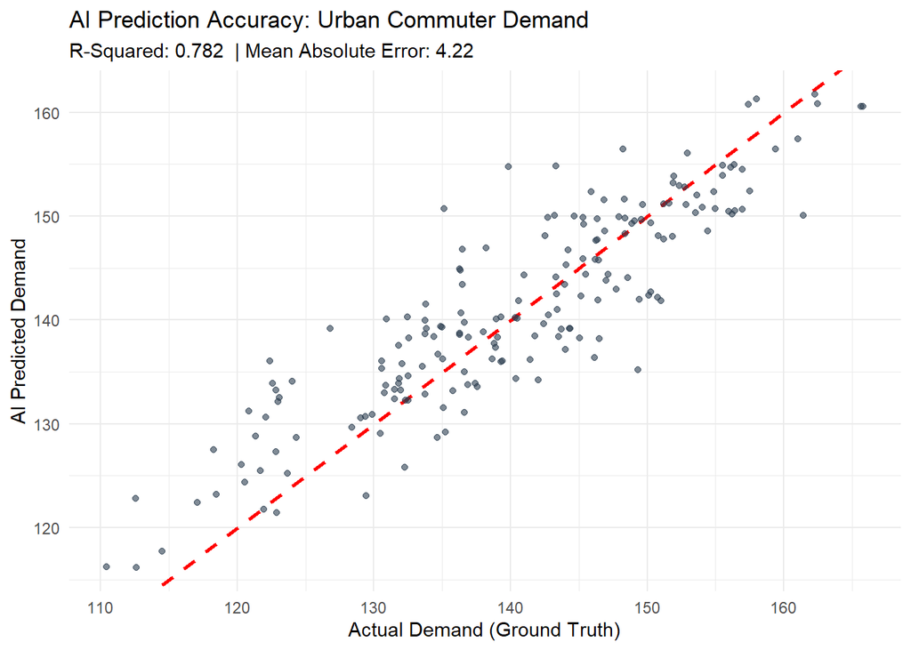

```r
comparison_results <- as.data.frame(h2o.cbind(test_data$CommuterDemand, predictions))
colnames(comparison_results) <- c("Actual_Demand", "AI_Prediction")

# Calculate metrics for the plot
r2_value <- round(h2o.r2(model_performance), 3)
mae_value <- round(h2o.mae(model_performance), 2)

ggplot(comparison_results, aes(x = Actual_Demand, y = AI_Prediction)) +
  geom_abline(slope = 1, intercept = 0, color = "red", linetype = "dashed", size = 1) +
  geom_point(alpha = 0.6, color = "#2c3e50") +
  theme_minimal() +
  labs(
    title = "AI Prediction Accuracy: Urban Commuter Demand",
    subtitle = paste("R-Squared:", r2_value, " | Mean Absolute Error:", mae_value),
    x = "Actual Demand (Ground Truth)",
    y = "AI Predicted Demand"
  )
```